# Cyclistic Bike Sharing

Rishabh Chaudhary

15-12-2022

### Google Analytics Certificate Case Study 1 - Cyclistic

#### Business Task:

Increasing annual members for Cyclistic, how casual riders can be converted to annual membership?

#### Stakeholders:

- Executives: Decision makers (detail-oriented)
- Lily Moreno: Marketing Manager (campaigns & initiatives)
- Marketing Analytics team

#### Read data for past 12 months

```r
# load the data.table package
library(data.table)

#library(data.table)
library("lubridate")
```

```r
library("ggplot2")
library("tidyverse")
library("dplyr")

# change working directory to Past_12_Months
setwd("C:/Users/RishabhChaudhary/Downloads/certs/Google Analytics Certificate/Case_Study_1_Cyclistic_Bike_Share/data/Past_12_Months/")

# Reading last 12 months data
df_past_12 <- as.data.frame(fread("Combined_12_months.csv"))
```

#### Inspect combined data

```r
#List of column names
print("Column Names:")
```

```
## [1] "Column Names:"
```

```r
colnames(df_past_12)
```

```
##  [1] "ride_id"            "rideable_type"      "started_at"
##  [4] "ended_at"           "start_station_name" "start_station_id"
##  [7] "end_station_name"   "end_station_id"     "start_lat"
## [10] "start_lng"          "end_lat"            "end_lng"
## [13] "member_casual"      "ride_length"        "day_of_week"
```

```r
#How many rows are in data frame?
print("Number of Records:")
```

```
## [1] "Number of Records:"
```

```r
nrow(df_past_12)
```

```
## [1] 5733451
```

```r
#Dimensions of the data frame?
print("Dimensions of dataset:")
```

```
## [1] "Dimensions of dataset:"
```

```r
dim(df_past_12)
```

```
## [1] 5733451      15
```

```r
#See the first 6 rows of data frame.  Also tail(all_trips)
print("Sample Records:")
```

```
## [1] "Sample Records:"
```

```r
head(df_past_12)
```

```
##            ride_id rideable_type       started_at         ended_at
## 1 46F8167220E4431F electric_bike  12/7/2021 15:06  12/7/2021 15:13
## 2 73A77762838B32FD electric_bike  12/11/2021 3:43  12/11/2021 4:10
## 3 4CF42452054F59C5 electric_bike 12/15/2021 23:10 12/15/2021 23:23
## 4 3278BA87BF698339  classic_bike 12/26/2021 16:16 12/26/2021 16:30
## 5 6FF54232576A3B73 electric_bike 12/30/2021 11:31 12/30/2021 11:51
## 6 93E8D79490E3AB11  classic_bike  12/1/2021 18:28  12/1/2021 18:38
##             start_station_name start_station_id           end_station_name
## 1     Laflin St & Cullerton St            13307        Morgan St & Polk St
## 2        LaSalle Dr & Huron St     KP1705001026 Clarendon Ave & Leland Ave
## 3 Halsted St & North Branch St     KA1504000117       Broadway & Barry Ave
## 4 Halsted St & North Branch St     KA1504000117      LaSalle Dr & Huron St
## 5     Leavitt St & Chicago Ave            18058     Clark St & Drummond Pl
## 6         Wabash Ave & 16th St           SL-012         Wells St & Polk St
##   end_station_id start_lat start_lng  end_lat   end_lng member_casual
## 1   TA1307000130  41.85483 -87.66366 41.87197 -87.65097        member
## 2   TA1307000119  41.89441 -87.63233 41.96797 -87.65000        casual
## 3          13137  41.89936 -87.64852 41.93758 -87.64410        member
## 4   KP1705001026  41.89939 -87.64854 41.89488 -87.63233        member
## 5   TA1307000142  41.89558 -87.68202 41.93125 -87.64434        member
## 6         SL-011  41.86038 -87.62581 41.87260 -87.63350        member
##   ride_length day_of_week
## 1         455           3
## 2        1614           7
## 3         766           4
## 4         883           1
## 5        1216           5
## 6         567           4
```

```r
#See list of columns and data types (numeric, character, etc)
print("Datatype of variables (columns):")
```

```
## [1] "Datatype of variables (columns):"
```

```r
str(df_past_12)
```

```
## 'data.frame':    5733451 obs. of  15 variables:
##  $ ride_id           : chr  "46F8167220E4431F" "73A77762838B32FD" "4CF42452054F59C5" "3278BA87BF698339" ...
##  $ rideable_type     : chr  "electric_bike" "electric_bike" "electric_bike" "classic_bike" ...
##  $ started_at        : chr  "12/7/2021 15:06" "12/11/2021 3:43" "12/15/2021 23:10" "12/26/2021 16:16" ...
##  $ ended_at          : chr  "12/7/2021 15:13" "12/11/2021 4:10" "12/15/2021 23:23" "12/26/2021 16:30" ...
##  $ start_station_name: chr  "Laflin St & Cullerton St" "LaSalle Dr & Huron St" "Halsted St & North Branch St" "Halsted St & North Branch St" ...
##  $ start_station_id  : chr  "13307" "KP1705001026" "KA1504000117" "KA1504000117" ...
##  $ end_station_name  : chr  "Morgan St & Polk St" "Clarendon Ave & Leland Ave" "Broadway & Barry Ave" "LaSalle Dr & Huron St" ...
##  $ end_station_id    : chr  "TA1307000130" "TA1307000119" "13137" "KP1705001026" ...
##  $ start_lat         : num  41.9 41.9 41.9 41.9 41.9 ...
##  $ start_lng         : num  -87.7 -87.6 -87.6 -87.6 -87.7 ...
##  $ end_lat           : num  41.9 42 41.9 41.9 41.9 ...
##  $ end_lng           : num  -87.7 -87.7 -87.6 -87.6 -87.6 ...
##  $ member_casual     : chr  "member" "casual" "member" "member" ...
##  $ ride_length       : int  455 1614 766 883 1216 567 358 1131 595 989 ...
##  $ day_of_week       : int  3 7 4 1 5 4 5 6 2 1 ...
```

```r
#Statistical summary of data. Mainly for numerics
print("Statistical Summary:")
```

```
## [1] "Statistical Summary:"
```

```r
summary(df_past_12)
```

```
##    ride_id          rideable_type       started_at          ended_at
##  Length:5733451     Length:5733451     Length:5733451     Length:5733451
##  Class :character   Class :character   Class :character   Class :character
##  Mode  :character   Mode  :character   Mode  :character   Mode  :character
##
##
##
##
##  start_station_name start_station_id   end_station_name   end_station_id
##  Length:5733451     Length:5733451     Length:5733451     Length:5733451
##  Class :character   Class :character   Class :character   Class :character
##  Mode  :character   Mode  :character   Mode  :character   Mode  :character
##
##
##
##
##    start_lat       start_lng         end_lat         end_lng
##  Min.   :41.64   Min.   :-87.84   Min.   : 0.00   Min.   :-88.14
##  1st Qu.:41.88   1st Qu.:-87.66   1st Qu.:41.88   1st Qu.:-87.66
##  Median :41.90   Median :-87.64   Median :41.90   Median :-87.64
##  Mean   :41.90   Mean   :-87.65   Mean   :41.90   Mean   :-87.65
##  3rd Qu.:41.93   3rd Qu.:-87.63   3rd Qu.:41.93   3rd Qu.:-87.63
##  Max.   :45.64   Max.   :-73.80   Max.   :42.37   Max.   :  0.00
##                                   NA's   :5874    NA's   :5874
##  member_casual       ride_length      day_of_week
##  Length:5733451     Min.   :     0   Min.   :1.000
##  Class :character   1st Qu.:   350   1st Qu.:2.000
##  Mode  :character   Median :   618   Median :4.000
##                     Mean   :  1064   Mean   :4.106
##                     3rd Qu.:  1110   3rd Qu.:6.000
##                     Max.   :359665   Max.   :7.000
##                     NA's   :835
```

#### Cleaning up and adding data to prepare for analysis

- Check distribution in different categories of member_casual

```r
# Home many categories in member_casual
table(df_past_12$member_casual)
```

```
##
##  casual  member
## 2346876 3386575
```

- Add columns that list the date, month, day, and year of each ride

```r
#The default format is yyyy-mm-dd
df_past_12$date <- as.Date(df_past_12$started_at, format = "%m/%d/%Y")
df_past_12$month <- format(as.Date(df_past_12$date), "%m")
df_past_12$day <- format(as.Date(df_past_12$date), "%d")
df_past_12$year <- format(as.Date(df_past_12$date), "%Y")
df_past_12$day_of_week <- format(as.Date(df_past_12$date), "%A")
```

- Inspect the structure of the columns

```r
str(df_past_12)
```

```
## 'data.frame':    5733451 obs. of  19 variables:
##  $ ride_id           : chr  "46F8167220E4431F" "73A77762838B32FD" "4CF42452054F59C5" "3278BA87BF698339" ...
##  $ rideable_type     : chr  "electric_bike" "electric_bike" "electric_bike" "classic_bike" ...
##  $ started_at        : chr  "12/7/2021 15:06" "12/11/2021 3:43" "12/15/2021 23:10" "12/26/2021 16:16" ...
##  $ ended_at          : chr  "12/7/2021 15:13" "12/11/2021 4:10" "12/15/2021 23:23" "12/26/2021 16:30" ...
##  $ start_station_name: chr  "Laflin St & Cullerton St" "LaSalle Dr & Huron St" "Halsted St & North Branch St" "Halsted St & North Branch St" ...
##  $ start_station_id  : chr  "13307" "KP1705001026" "KA1504000117" "KA1504000117" ...
##  $ end_station_name  : chr  "Morgan St & Polk St" "Clarendon Ave & Leland Ave" "Broadway & Barry Ave" "LaSalle Dr & Huron St" ...
##  $ end_station_id    : chr  "TA1307000130" "TA1307000119" "13137" "KP1705001026" ...
##  $ start_lat         : num  41.9 41.9 41.9 41.9 41.9 ...
##  $ start_lng         : num  -87.7 -87.6 -87.6 -87.6 -87.7 ...
##  $ end_lat           : num  41.9 42 41.9 41.9 41.9 ...
##  $ end_lng           : num  -87.7 -87.7 -87.6 -87.6 -87.6 ...
##  $ member_casual     : chr  "member" "casual" "member" "member" ...
##  $ ride_length       : int  455 1614 766 883 1216 567 358 1131 595 989 ...
##  $ day_of_week       : chr  "Tuesday" "Saturday" "Wednesday" "Sunday" ...
##  $ date              : Date, format: "2021-12-07" "2021-12-11" ...
##  $ month             : chr  "12" "12" "12" "12" ...
##  $ day               : chr  "07" "11" "15" "26" ...
##  $ year              : chr  "2021" "2021" "2021" "2021" ...
```

- Check distribution in different categories of start_station_name

```r
# Home many categories in start_station_name
table(df_past_12$start_station_name == 'HQ QR')
```

```
##
##   FALSE
## 4878607
```

#### Conducting descriptice anlysis

- Descriptive analysis on ride_length

```r
# Summary of ride_length
summary(df_past_12$ride_length)
```

```
##    Min. 1st Qu.  Median    Mean 3rd Qu.    Max.    NA's
##       0     350     618    1064    1110  359665     835
```

- Comparing members and casual users

```r
aggregate(df_past_12$ride_length ~ df_past_12$member_casual, FUN = mean)
```

```
##   df_past_12$member_casual df_past_12$ride_length
## 1                   casual              1499.0851
## 2                   member               762.5375
```

```r
aggregate(df_past_12$ride_length ~ df_past_12$member_casual, FUN = median)
```

```
##   df_past_12$member_casual df_past_12$ride_length
## 1                   casual                    783
## 2                   member                    530
```

```r
aggregate(df_past_12$ride_length ~ df_past_12$member_casual, FUN = max)
```

```
##   df_past_12$member_casual df_past_12$ride_length
## 1                   casual                 359665
## 2                   member                  93594
```

```r
aggregate(df_past_12$ride_length ~ df_past_12$member_casual, FUN = min)
```

```
##   df_past_12$member_casual df_past_12$ride_length
## 1                   casual                      0
## 2                   member                      0
```

- See the average ride time by each day for members vs casual users

```r
# Fix order of week days
df_past_12$day_of_week <- ordered(df_past_12$day_of_week, levels=c("Sunday", "Monday", "Tuesday", "Wednesday", "Thursday", "Friday", "Saturday"))

aggregate(df_past_12$ride_length ~ df_past_12$member_casual + df_past_12$day_of_week, FUN = mean)
```

```
##    df_past_12$member_casual df_past_12$day_of_week df_past_12$ride_length
## 1                    casual                 Sunday              1724.7761
## 2                    member                 Sunday               842.8941
## 3                    casual                 Monday              1535.8960
## 4                    member                 Monday               736.4146
## 5                    casual                Tuesday              1354.1618
## 6                    member                Tuesday               728.8662
## 7                    casual              Wednesday              1289.1009
## 8                    member              Wednesday               723.9585
## 9                    casual               Thursday              1337.3392
## 10                   member               Thursday               737.9848
## 11                   casual                 Friday              1417.3700
## 12                   member                 Friday               750.0025
## 13                   casual               Saturday              1660.0196
## 14                   member               Saturday               849.0422
```

- analyze ridership data by type and weekday

```r
# creates weekday field using wday()
# groups by usertype and weekday
# calculates the number of rides and average duration
# calculates the average duration
# sorts the data
df_past_12 %>%
  group_by(member_casual, day_of_week) %>%
  summarise(number_of_rides = n(), average_duration = mean(ride_length)) %>%
  arrange(member_casual, day_of_week)
```

```
## # A tibble: 14 × 4
## # Groups:   member_casual [2]
##    member_casual day_of_week number_of_rides average_duration
##    <chr>         <ord>                 <int>            <dbl>
##  1 casual        Sunday               392130               NA
##  2 casual        Monday               280472               NA
##  3 casual        Tuesday              264068               NA
##  4 casual        Wednesday            279380               NA
##  5 casual        Thursday             313739               NA
##  6 casual        Friday               340499               NA
##  7 casual        Saturday             476588               NA
##  8 member        Sunday               390502               NA
##  9 member        Monday               476935               NA
## 10 member        Tuesday              518665               NA
## 11 member        Wednesday            537745               NA
## 12 member        Thursday             540347               NA
## 13 member        Friday               476908               NA
## 14 member        Saturday             445473               NA
```

- Let’s visualize the number of rides by rider type

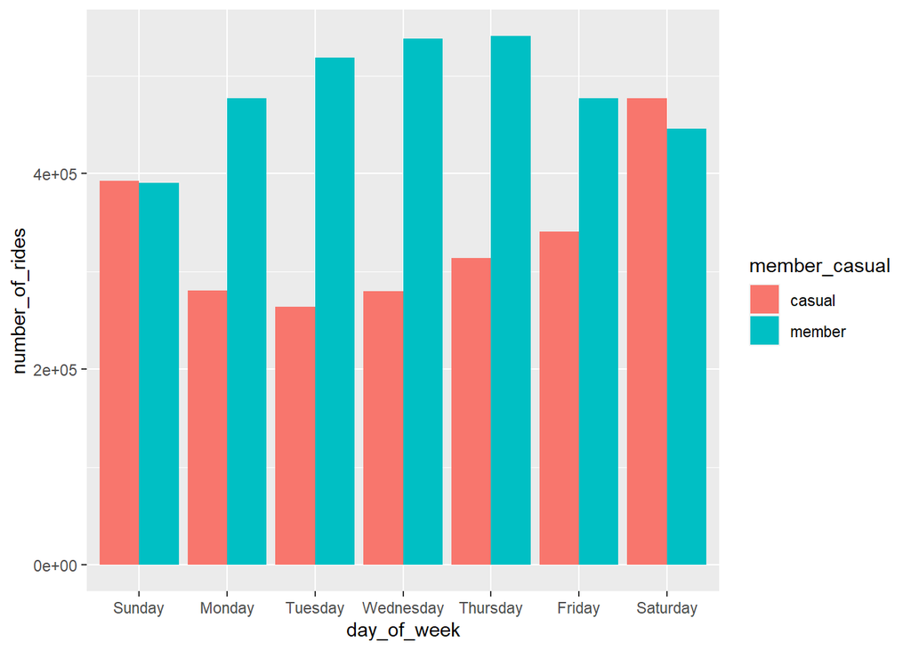

```r
df_past_12 %>%
  group_by(member_casual, day_of_week) %>%
  summarise(number_of_rides = n()
            ,average_duration = mean(ride_length, na.rm=TRUE)) %>%
  arrange(member_casual, day_of_week)  %>%
  ggplot(aes(x = day_of_week, y = number_of_rides, fill = member_casual)) +
  geom_col(position = "dodge")
```

- Let’s create a visualization for average duration

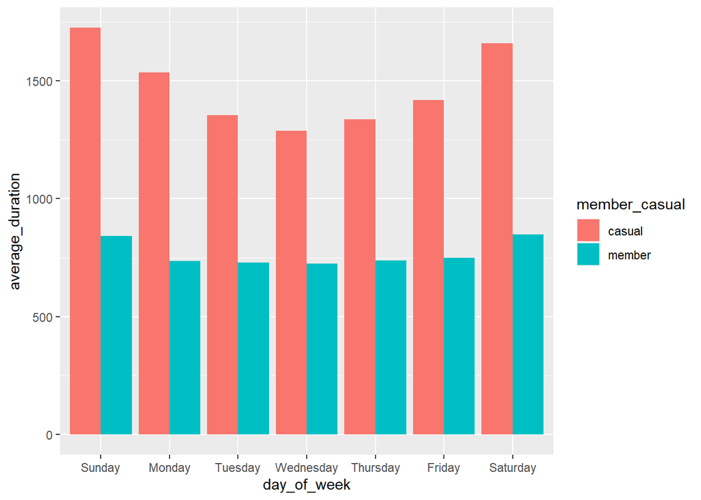

```r
df_past_12 %>%
  group_by(member_casual, day_of_week) %>%
  summarise(number_of_rides = n()
            ,average_duration = mean(ride_length, na.rm=TRUE)) %>%
  arrange(member_casual, day_of_week) %>%
  ggplot(aes(x = day_of_week, y = average_duration, fill = member_casual)) +
  geom_col(position = "dodge")
```

#### Export summary file for further analysis

- Create a csv file that we will visualize in Excel, Tableau, or my presentation software

```r
counts <- aggregate(df_past_12$ride_length ~ df_past_12$member_casual + df_past_12$day_of_week, FUN = mean)

setwd("C:/Users/RishabhChaudhary/Downloads/certs/Google Analytics Certificate/Case_Study_1_Cyclistic_Bike_Share/data/Past_12_Months/")

fwrite(as.data.table(counts), "avg_ride_length.csv")
```